# Lab 0: Introduction to ADQL and the Gaia Data Release 2

# 1. Introduction

We will in this report study three known clusters, using the newly released Gaia Data Release 2. After locating and identifying all assumed member of the clusters, we will construct a color - absolute magnitude (HR) digram for each cluster, hopefully resulting in a nice isochrone.

To identify the members of each cluster, we will use known values for their angular location, parallax, and proper motion. After studying the behaviour of these parameters around the known values, we will apply resonable filters to their values, in order to pick out the cluster bodies.

In addition, we will employ some relatively strict noise-reducing filters, to remove any potentially bad data. As our final goal is not to constuct a most complete set of likely cluster members, but to construct an accurate isochrone, quality beats quantity.

## 1.1 The clusters and their properties

The clusters we will study are

1. **The Hyades**: An open, young cluster, only an estimated 625 million years old. It is also the clostest of the three, at only 47 pc.
2. **M67 (or NGC 2682)**: An open, much older cluster, estimated to be somewhere from 3 to 5 billion years old. It is also much farther away, at over 800 pc.
3. **NGC 6397**: A globular cluster, even older, somewhere around 13 billion years old. Also the most remote, at 2.4kpc.

We start this lab by gathering some data about each cluster, which will all be usefull in our analysis. Most data is gathered from reputable papers on the Gaia DR2.

[output not shown]

Table 1: Parameters of interest for the three clusters.

[1] Values gathered from the Gaia DR2 itself, where you can search for a cluster and get a corresponding ADQL query. The query contains a set of parameters, which can be extracted.

[2] Babusiaux et al. 2018 (about construction of color-magnitude diagrams with Gaia; arxiv: 1804.09378)

[3] A. Helmi et al. 2018 (Gaia Data Release 2: Kinematics of globular clusters and dwarf galaxies around the Milky Way; arXiv:1804.09381)

# 2. Data collection and initial filtering

## 2.1 Noise Filters

The Gaia Data Release 2 contains well over a billion celestial bodies. The accuracy of measurement will necessarily vary widely from object to object. As our aim is to derive an isocrone as accurate as possible, quality beats quantity, and we will employ a series of filters aimed at removing potentially bad data. The filters are found in the appendix of Babusiaux et al.<sup>[2]</sup>, and are described in section 2.1 of the paper.

The effect of some of the most important filters are listed here.

- `visibility_periods_used`: To my understanding, this is the number of "independent" observations of the object for at least 4 days, separated from other objects.
- `parallax_over_error`: The ratio of parallax to parallax_error is required to be above a factor 10.
- `phot_**_mean_flux_over_error`: Similar requirements to the errors of other parameters.
- `phot_bp_rp_excess_factor` and `phot_bp_mean_mag-phot_rp_mean_mag`: This is an attempt to reduce noise and blur from nearby and background light-sources.

The filters seem well fit for relatively close and open clusters, where noise levels are reasonably low, and parallax measurements are accurate. We will loosen the filter values somewhat in the globular, farther away cluster.

We apply these filters into an ADQL query, and access the Gaia servers with the astroquer package, as shown below. We will later append cluster-specific filters to this query.

```python
import numpy as np
import matplotlib.pyplot as plt
%matplotlib inline
import astroquery.utils.tap.core
import pandas
from astroquery.utils.tap.core import TapPlus
import warnings
warnings.filterwarnings('ignore')

gaia = TapPlus(url="http://gea.esac.esa.int/tap-server/tap")
```

```
Created TAP+ (v1.0.1) - Connection:
	Host: gea.esac.esa.int
	Use HTTPS: False
	Port: 80
	SSL Port: 443
```

## 2.2 Cluster ra/dec filtering and queries

We will now pull down Gaia data in the approximate "angular area" of the three clusters (right ascension and declination). The angles are chosen very liberally, around twice the assumed size of the clusters, to ensure we get the entire clusters. We will instead employ stricter parallax and proper motion cuts, to ensure only cluster members are chosen.

While most information we desire is directly avaliable as columns in the Gaia archive, we will constuct the *Gaia magnitude* `mg` as `phot_g_mean_mag+5*log10(parallax)-10`, as suggested in Babusiaux et al. 2018<sup>[2]</sup>.

### 2.2.1 Hyades Query

The Hyades has a known apparent dimension of around 5 degrees, and we choose to employ a comfortable 10 degree circle (5 degree radius) around its estimated center.

```python
Hyades_ADQL_query="""
SELECT ra, ra_error, dec, dec_error, pmra, pmdec, parallax, parallax_error, phot_g_mean_mag+5*log10(parallax)-10 AS mg, bp_rp
FROM gaiadr2.gaia_source
WHERE
    parallax_over_error > 10
AND phot_g_mean_flux_over_error>50
AND phot_rp_mean_flux_over_error>20
AND phot_bp_mean_flux_over_error>20
AND phot_bp_rp_excess_factor < 1.3+0.06*power(phot_bp_mean_mag-phot_rp_mean_mag,2)
AND phot_bp_rp_excess_factor > 1.0+0.015*power(phot_bp_mean_mag-phot_rp_mean_mag,2)
AND visibility_periods_used>8
AND astrometric_chi2_al/(astrometric_n_good_obs_al-5)<1.44*greatest(1,exp(-0.4*(phot_g_mean_mag-19.5)))
AND CONTAINS(
        POINT('ICRS', gaiadr2.gaia_source.ra, gaiadr2.gaia_source.dec),
        CIRCLE('ICRS', 66.725, 15.86667, 5)
    )=1
"""

job = gaia.launch_job_async(Hyades_ADQL_query)
data_Hyades = job.get_results()
```

```
Query finished.
```

### 2.2.2 M67 Query

The M67 has a known apparent dimension of around 1/2 degree, and we employ a 1 degree search around its estimated center.

```python
M67_ADQL_query="""
SELECT ra, ra_error, dec, dec_error, pmra, pmdec, parallax, parallax_error, phot_g_mean_mag+5*log10(parallax)-10 AS mg, bp_rp
FROM gaiadr2.gaia_source
WHERE
    parallax_over_error > 10
AND phot_g_mean_flux_over_error>50
AND phot_rp_mean_flux_over_error>20
AND phot_bp_mean_flux_over_error>20
AND phot_bp_rp_excess_factor < 1.3+0.06*power(phot_bp_mean_mag-phot_rp_mean_mag,2)
AND phot_bp_rp_excess_factor > 1.0+0.015*power(phot_bp_mean_mag-phot_rp_mean_mag,2)
AND visibility_periods_used>8
AND astrometric_chi2_al/(astrometric_n_good_obs_al-5)<1.44*greatest(1,exp(-0.4*(phot_g_mean_mag-19.5)))
AND CONTAINS(
        POINT('ICRS', gaiadr2.gaia_source.ra, gaiadr2.gaia_source.dec),
        CIRCLE('ICRS', 132.825, 11.8, 0.5)
    )=1
"""

job = gaia.launch_job_async(M67_ADQL_query)
data_M67 = job.get_results()
```

```
Query finished.
```

### 2.2.3 NGC 6397 Query

The NGC 6397 also has an apparent dimension of around 1/2 degree, and we again employ a 1 degree search around its estimated center.

We relax the `parallax_over_error` condition to a ratio of 4, as suggested in A. Helmi et al. 2018<sup>[3]</sup>, section 2.1 on filtering of globular clusters(the paper reduced it all the way down to 2, which we believe is a bit too generious, as it gave much more noise to the final solution). We have also slightly reduced the ratios for other error tolerances.

```python
NGC6397_ADQL_query="""
SELECT ra, ra_error, dec, dec_error, pmra, pmdec, parallax, parallax_error, phot_g_mean_mag+5*log10(parallax)-10 AS mg, bp_rp
FROM gaiadr2.gaia_source
WHERE
    parallax_over_error > 4
AND phot_g_mean_flux_over_error>35
AND phot_rp_mean_flux_over_error>15
AND phot_bp_mean_flux_over_error>15
AND phot_bp_rp_excess_factor < 1.3+0.06*power(phot_bp_mean_mag-phot_rp_mean_mag,2)
AND phot_bp_rp_excess_factor > 1.0+0.015*power(phot_bp_mean_mag-phot_rp_mean_mag,2)
AND visibility_periods_used>8
AND astrometric_chi2_al/(astrometric_n_good_obs_al-5)<1.44*greatest(1,exp(-0.4*(phot_g_mean_mag-19.5)))
AND CONTAINS(
        POINT('ICRS', gaiadr2.gaia_source.ra, gaiadr2.gaia_source.dec),
        CIRCLE('ICRS', 265.175375, -53.674333, 0.5)
    )=1
"""

job = gaia.launch_job_async(NGC6397_ADQL_query)
data_NGC6397 = job.get_results()
```

```
Query finished.
```

# 3. Data analysis and further filtering

## 3.1 Hyades

```python
data_Hyades = data_Hyades.to_pandas()
print(f"Original query gives {data_Hyades.shape[0]} celestial bodies")
```

```
Original query gives 57454 celestial bodies
```

```python
parallax_estimate_Hyades = 21.052
pmra_estimate_Hyades = 101.005
pmdec_estimate_Hyades = -28.490
```

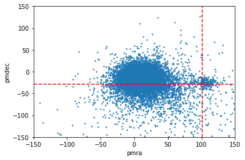

```python
data_Hyades.plot.scatter('pmra','pmdec', xlim=(-150, 150), ylim=(-150,150), s=2)
plt.axvline(x=pmra_estimate_Hyades, ls='--', c='r')
plt.axhline(y=pmdec_estimate_Hyades, ls='--', c='r')
```

Taking a quick look at the phase space, we see that the cluster is well localized and visible. The phase space locations seems a bit off, and we will adjust is slightly after taking a look at the clusters parallax.

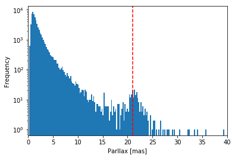

```python
data_Hyades['parallax'].plot.hist(bins=500, xlim=(0,40), logy=True)
plt.axvline(x = parallax_estimate_Hyades, ls='--', c='r')
plt.xlabel("Parllax [mas]")
```

The Hyades is very close, but its also a rather small cluster. A logarithmic parallax histogram does, however, give its location away. From the plot above, we see that a local maximum corresponds with our pressumed position of the cluster.

We begin by applying a generous cut to the parallax

```python
parallax_tol_Hyades = 2

data_cut_Hyades_1 = data_Hyades.copy()
data_cut_Hyades_1 = data_cut_Hyades_1[np.abs(data_cut_Hyades_1['parallax'] - parallax_estimate_Hyades) < parallax_tol_Hyades ]
print(f"The parallax cut reduced the number of celestial bodies from {data_Hyades.shape[0]} to {data_cut_Hyades_1.shape[0]}.")
```

```
The parallax cut reduced the number of celestial bodies from 57454 to 190.
```

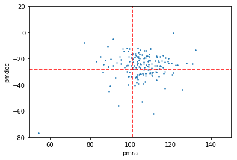

```python
data_cut_Hyades_1.plot.scatter('pmra','pmdec', xlim=(50, 150), ylim=(-80, 20), s=2)
plt.axvline(x=pmra_estimate_Hyades, ls='--', c='r')
plt.axhline(y=pmdec_estimate_Hyades, ls='--', c='r')
```

The proper motion center actually seems a bit off, so we do a quick re-adjustment by eye, and do a proper motion cut.

```python
pmra_estimate_Hyades = 106
pmdec_estimate_Hyades = -26

pm_tol_Hyades = 15

data_cut_Hyades_2 = data_cut_Hyades_1[np.sqrt((data_cut_Hyades_1['pmra'] - pmra_estimate_Hyades)**2 +
                                    (data_cut_Hyades_1['pmdec'] - pmdec_estimate_Hyades)**2) < pm_tol_Hyades]


print(f"The proper motion cut further reduced the number of celestial bodies to {data_cut_Hyades_2.shape[0]}.")
```

```
The proper motion cut further reduced the number of celestial bodies to 136.
```

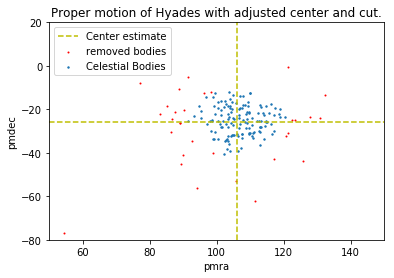

```python
removed_data = data_cut_Hyades_1[~data_cut_Hyades_1.isin(data_cut_Hyades_2)]
ax = removed_data.plot.scatter('pmra','pmdec', c='r', s=1, xlim=(50, 150), ylim=(-80, 20), label="removed bodies")

data_cut_Hyades_2.plot.scatter('pmra','pmdec', xlim=(50, 150), ylim=(-80, 20), s=2, ax=ax, label="Celestial Bodies")
plt.axvline(x=pmra_estimate_Hyades, ls='--', c='y', label="Center estimate")
plt.axhline(y=pmdec_estimate_Hyades, ls='--', c='y')
plt.title("Proper motion of Hyades with adjusted center and cut.")
plt.legend()
```

Above we see the remainding and removed phase space bodies.

As a final sanity-check, I plot the same logarithmic parallax histogram we started with, but this time subtracting all the celestial bodies we concluded to be part of the Hyades cluster. The idea is that, removing the cluster, the parallax should follow a somewhat natural curve, without any apperant lack of, or abudance of, celestial bodies at any particular parallax.

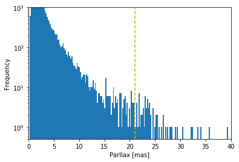

```python
test_data = data_Hyades.copy()
test_data = test_data[~test_data.isin(data_cut_Hyades_2)].dropna()
test_data['parallax'].plot.hist(bins=500, logy=True, ylim=(0.5, 1000), xlim=(0, 40))
plt.axvline(x=parallax_estimate_Hyades, ls="--", c="y")
plt.xlabel("Parllax [mas]")
```

We see that the parallax indeed forms a much more natural shape in the end, albeit a bit noisy.

## 3.2 M67

```python
data_M67 = data_M67.to_pandas()
print(f"The original data set contains {data_M67.shape[0]} celestial bodies.")
```

```
The original data set contains 1489 celestial bodies.
```

```python
parallax_estimate_M67 = 1.1325
pmra_estimate_M67 = -10.9737  #(mas/yr) babuslaux
pmdec_estimate_M67 = -2.9396
```

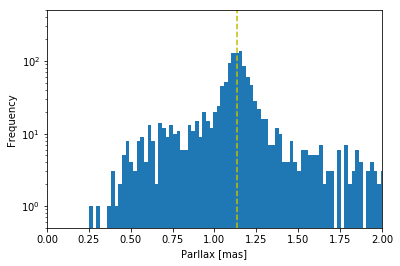

```python
data_M67['parallax'].plot.hist(bins=1000, logy=True, ylim=(0.5, 500), xlim=(0, 2))
plt.axvline(x=parallax_estimate_M67, ls="--", c="y")
plt.xlabel("Parllax [mas]")
```

Above we have plotted the parallax of the M67 in the same fashion as for the Hyades, and do indeed confirm that the M67's parallax is visible. We perform a cut:

```python
parallax_tol_M67 = 0.3

data_cut_M67_1 = data_M67.copy()

data_cut_M67_1 = data_cut_M67_1[np.abs(data_cut_M67_1['parallax'] - parallax_estimate_M67) < parallax_tol_M67]

print(f"The parallax cut reduced the number of bodies to {data_cut_M67_1.shape[0]}")
```

```
The parallax cut reduced the number of bodies to 1043
```

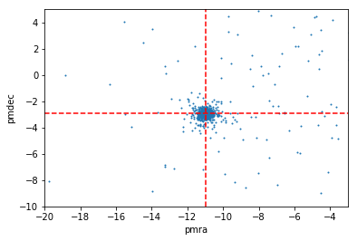

```python
data_cut_M67_1.plot.scatter('pmra','pmdec', xlim=(-20, -3), ylim=(-10, 5), s=1)
plt.axvline(x=pmra_estimate_M67, ls='--', c='r')
plt.axhline(y=pmdec_estimate_M67, ls='--', c='r')
```

Next, plotting the proper motion space, everything looks rather good. The cluster is very localized, and we perform a cut:

```python
pm_tol_M67 = 0.6

data_cut_M67_2 = data_cut_M67_1[np.sqrt((data_cut_M67_1['pmra'] - pmra_estimate_M67)**2 +
                                    (data_cut_M67_1['pmdec'] - pmdec_estimate_M67)**2) < pm_tol_M67]

print(f"The proper motion cut reduced the celestial bodies to {data_cut_M67_2.shape[0]}")
```

```
The proper motion cut reduced the celestial bodies to 723
```

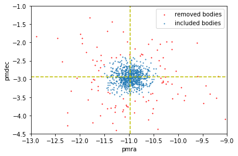

```python
removed_data = data_cut_M67_1[~data_cut_M67_1.isin(data_cut_M67_2)]
ax = removed_data.plot.scatter('pmra','pmdec', c='r', s=1, xlim=(-13, -9), ylim=(-4.5, -1), label="removed bodies")
data_cut_M67_2.plot.scatter('pmra','pmdec', s=1, xlim=(-13, -9), ylim=(-4.5, -1), ax=ax, label="included bodies")
plt.axvline(x=pmra_estimate_M67, ls='--', c='y')
plt.axhline(y=pmdec_estimate_M67, ls='--', c='y')
```

Above, we see the bodies removed as a part of our proper motion cut.

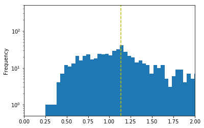

```python
test_data = data_M67.copy()
test_data = test_data[~test_data.isin(data_cut_M67_2)].dropna()
test_data['parallax'].plot.hist(bins=500, logy=True, xlim=(0, 2), ylim=(0.5, 500))
plt.axvline(x=parallax_estimate_M67, ls="--", c="y")
```

At last, our Parallax sanity check, as described in the Hyades section, shows that we have removed the obvious precende of a cluster from the parallax, without removing "too much" either.

## 3.3 NGC 6397

```python
data_NGC6397 = data_NGC6397.to_pandas()
print(f"Original number of celestial bodies in data is {data_NGC6397.shape[0]}")
```

```
Original number of celestial bodies in data is 11190
```

```python
parallax_estimate_NGC6397 = 0.3781
pmra_estimate_NGC6397 = 3.2908
pmdec_estimate_NGC6397 = -17.5908
```

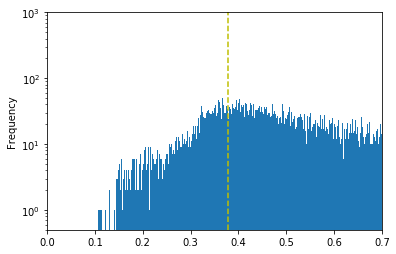

```python
data_NGC6397['parallax'].plot.hist(bins=10000, logy=True, ylim=(0.5, 1000), xlim=(0, 0.7))
plt.axvline(x=parallax_estimate_NGC6397, ls="--", c="y") #This one is slow, sorry :)
```

As expected, there isn't really much evidence of the NGC6397 in the Parallax plot. We will therefore employ a somewhat generous range to the parallax values. (Note that as the parallax goes inversely with distance, a 0.2 parallax tolerance for a cluster this far away corresponds to a much larger euclidian distance than it would for a more nearby cluster).

```python
parallax_tol_NGC6397 = 0.2

data_cut_NGC6397_1 = data_NGC6397.copy()

data_cut_NGC6397_1 = data_cut_NGC6397_1[ np.abs(data_cut_NGC6397_1['parallax'] -\
                                            parallax_estimate_NGC6397) < parallax_tol_NGC6397]

print(f"The parallax cut reduced the number of bodies to {data_cut_NGC6397_1.shape[0]}")
```

```
The parallax cut reduced the number of bodies to 6247
```

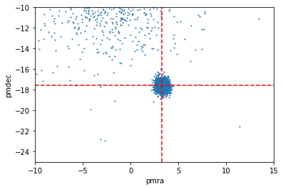

```python
data_cut_NGC6397_1.plot.scatter('pmra','pmdec', s=1, xlim=(-10,15), ylim=(-25,-10))
plt.axvline(x=pmra_estimate_NGC6397, ls='--', c='r')
plt.axhline(y=pmdec_estimate_NGC6397, ls='--', c='r')
```

The proper motion plot again reveals a very nicely localized cluster. We perform a cut:

```
(2650, 10)
```

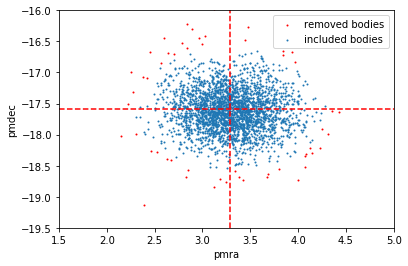

```python
pm_tol_NGC6397 = 1


data_cut_NGC6397_2 = data_cut_NGC6397_1[np.sqrt((data_cut_NGC6397_1['pmra'] - pmra_estimate_NGC6397)**2 +
                                    (data_cut_NGC6397_1['pmdec'] - pmdec_estimate_NGC6397)**2) < pm_tol_NGC6397]

print(data_cut_NGC6397_2.shape)
removed_data = data_cut_NGC6397_1[~data_cut_NGC6397_1.isin(data_cut_NGC6397_2)]
ax = removed_data.plot.scatter('pmra','pmdec', c='r', s=1, xlim=(1.5,5), ylim=(-19.5,-16), label="removed bodies")
data_cut_NGC6397_2.plot.scatter('pmra','pmdec', s=1, xlim=(1.5,5), ylim=(-19.5,-16), ax=ax, label="included bodies")
plt.axvline(x=pmra_estimate_NGC6397, ls='--', c='r')
plt.axhline(y=pmdec_estimate_NGC6397, ls='--', c='r')
```

# 4. HR Diagrams and Conclusion

We now turn to the main target of this lab, the construction of color - magnitude diagrams for the three clusters. For our Gaia data, this is very straightforward, as we have direct acces to magnitude and R-B data.

```python
def get_isochrone(filename):
    """Returns an isochrone (bp_rp & mg) from a MIST generated .cmd isochrone file."""
    bp_rp = []
    mg = []
    with open(filename, "r") as infile:
        for i in range(13):  # Skipping info lines.
            infile.readline()
        for line in infile:
            words = line.split()
            mg.append(float(words[22]))
            bp_rp.append(float(words[23])-float(words[24]))
    bp_rp = np.array(bp_rp)
    mg = np.array(mg)
    return bp_rp, mg
```

## 4.1 Hyades

From the figure below, we see that the Hyades cluster creates a thin, welldefined strip along the main-sequence isochrone. Both its length and lack of width confirms its young age. The data falls slightly above the theoretical isochrone. The isochrone of a slightly older cluster would be skewed this way, but it would also crumble it's top-left tail further down, where we see that the data fits quite well. A right-shift of the isochrone is also accomplished by a higher assumed extinction level, but at the cluster is very close to earth, this seems unlikely.

Neither of these explanations are very satisfactory however, as all these parameters are already estiblished by many astronomers. The real explanation is likely something more mundane, like the lack of account for other variables, or simply inaccuracy in our isochrone generator(or data).

The cluster does either way form a nice thin line due to its age, making us able to clearly observe a handful of binary stars, which lie scattered slightly above the data's isochrone. There appears to be at least 5 or 10 in our current dataset, although it should be mentioned that binary stars are more often lost than their single simblings during data cleansing, as outlines in section 2.1 of Babusiaux et al. 2018<sup>[2]</sup>.

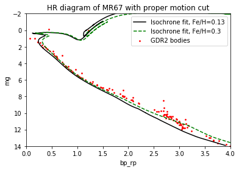

```python
bp_rp_Hyades, mg_Hyades = get_isochrone("MIST_Hyades.cmd")
bp_rp_Hyades2, mg_Hyades2 = get_isochrone("MIST_Hyades_2.cmd")
data_cut_Hyades_2.plot.scatter('bp_rp', 'mg', ylim=(14,-1), c='r', s=3, label='GDR2 bodies')
plt.plot(bp_rp_Hyades, mg_Hyades, c='k', linewidth=1.5, label='Isochrone fit, Fe/H=0.13')
plt.plot(bp_rp_Hyades2, mg_Hyades2, c='g', ls='--', linewidth=1.5, label='Isochrone fit, Fe/H=0.3')
plt.xlim(0,4)
plt.ylim(14,-2)
plt.legend()
plt.title("HR diagram of MR67 with proper motion cut")
```

## 4.2 M67

Below we see the HR diagram of the M67 cluster. In similar fashion to the Hyades cluster, the data falls slightly above (albeit touching) the theoretical isochrone line. This could also be explained by one of the factors mentioned above. Some bodies also lie scattered left and above the isochrone, and probably does not belong to the cluster, but a main-series isochrone. The upper tail("turn-off point") of the data fits very well with the isochrone, bending in the exact same way. We see the cluster is evolving away from the main sequence, and stars have started evolving into giants.

Some binary stars seem very plausible, although due to the higher level of spread and noise, it is harder to say for sure.

Finally, comparing to the HR diagram without a proper motion cut, there is not really that much difference, perhaps suggesting we could have been even more strict in our cuts.

```
(14, -3)
```

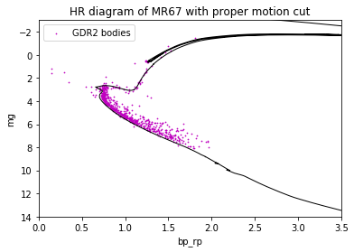

```python
bp_rp_M67, mg_M67 = get_isochrone("MIST_M67.cmd")
data_cut_M67_2.plot.scatter('bp_rp', 'mg', ylim=(14,-1), c='m', s=0.5, label='GDR2 bodies')
plt.plot(bp_rp_M67, mg_M67, c='k', linewidth=1)
plt.title("HR diagram of MR67 with proper motion cut")
plt.xlim(0,3.5)
plt.ylim(14,-3)
```

## 4.3 NGC6397

The NGC6397 cluster shows a rather different shape than the two open clusters, many stars having moved away from the main sequence. We see that the upper left portion of the main sequence is entirely gone, having evolved into giants, and some bodies having moved all the way over to the horizontal branch.

The original isochrone fit for the NGC6397 was particularly peculiar, cutting off very low at the main sequence, and stopping there. Increasing the Fe/H ratio slightly created a much better fit, showing the raminding main sequence, the giants, and the horizontal branch.

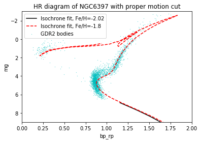

```python
data_cut_NGC6397_2.plot.scatter('bp_rp', 'mg', c='c', s=0.05, label='GDR2 bodies')
bp_rp_NGC6397, mg_NGC6397 = get_isochrone("MIST_NGC6397.cmd")
bp_rp_NGC6397_2, mg_NGC6397_2 = get_isochrone("MIST_NGC6397_5.cmd")
plt.plot(bp_rp_NGC6397, mg_NGC6397, c='k', label='Isochrone fit, Fe/H=-2.02')
plt.plot(bp_rp_NGC6397_2, mg_NGC6397_2, c='r', ls='--', linewidth=1.5, label='Isochrone fit, Fe/H=-1.8')
plt.ylim(9,-3)
plt.xlim(0,2)
plt.title("HR diagram of NGC6397 with proper motion cut")
plt.legend()
```

## Comparing to initial case

Below we see the HR diagrams of the original angular sections of the sky without any cuts to parallax or proper motion. There is not doubt the cuts are required to pick out the cluster members. We clearly see that when comparing stars not of the same age (and origin), the HR diagram becomes a mess.

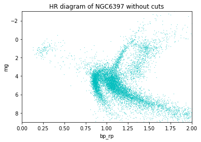

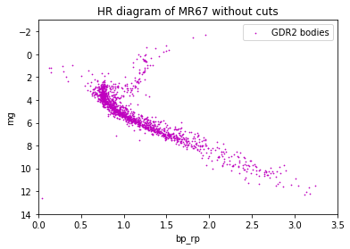

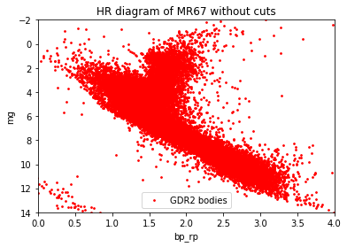

```python
data_NGC6397.plot.scatter('bp_rp', 'mg', c='c', s=0.05)
plt.ylim(9,-3)
plt.xlim(0,2)
plt.title("HR diagram of NGC6397 without cuts")

data_M67.plot.scatter('bp_rp', 'mg', ylim=(14,-1), c='m', s=0.5, label='GDR2 bodies')
plt.title("HR diagram of MR67 without cuts")
plt.xlim(0,3.5)
plt.ylim(14,-3)

data_Hyades.plot.scatter('bp_rp', 'mg', ylim=(14,-1), c='r', s=3, label='GDR2 bodies')
plt.xlim(0,4)
plt.ylim(14,-2)
plt.legend()
plt.title("HR diagram of MR67 without cuts")
```

# Final Notes

Taking a final look at the total number of celestial bodies observed in each cluster, we can see that our own estimate varies from 12% to 61% of established number of bodies. That our hit-rate is low in the further, globular cluster, is no surprise. That the M67 has such a good hit-rate (compared to Hyades) is however quite interesting. We might have picket up some non-cluster celestial bodies, as the HR diagram is somewhat noisy, and we would not really expect it to have a higher hit-rate than Hyades, with its very clean parallax cut. We did, however, keep the noise filters the same as Hyades, even though M67 is substansially further away.

For the NGC 6397, there is no doubt that the noise filters picked away a lot of bodies, as we are left with only half its supposed number of stars after only the angular position cut.

One other expected remark is the extreme effectiveness of the Parallax cut on Hyades, reducing the number of bodies by 99.7%.

| Property / Cluster | Hyades | M67 | NGC 6397 |
| --- | --- | --- | --- |
| *Objects after ra/dec cut* | 57454 | 1489 | 11190 |
| *Objects after parallax cut* | 190 | 1043 | 6247 |
| *Objects after proper motion cut* | 136 | 723 | 2650 |
| *Source Estimates (table1)* | 480 | 1194 | 22116 |
| *Percentage picked up* | 29% | 61% | 12% |

Table2: Remainding celestial bodies after given cuts.

# Future Work

We could definitively have run our sanity checks also in proper motion and angular position space, to confirm uniformity.

The cuts in parallax, angle and proper motion, while effective enough, were nothing more that qualified guesses from a human eye. More powerful methods of cluster-searching should definitively be employed in the future.